Table of Contents ... Local, [Github](https://github.com/renyuanL/_ryProb2020/blob/master/index.ipynb), [Colab](https://colab.research.google.com/github/renyuanL/_ryProb2020/blob/master/index.ipynb).

Current Chapter ... Local, [Github](https://github.com/renyuanL/_ryProb2020/blob/master/probCh01.ipynb), [Colab](https://colab.research.google.com/github/renyuanL/_ryProb2020/blob/master/probCh01.ipynb).

# 1. Introduction to Statistics and Probability

- 1.1 Overview: Statistical Inference, Samples, Populations, and the Role of Probability
- 1.2 Sampling Procedures; Collection of Data
- 1.3 Discrete and Continuous Data.
- 1.4 Probability: Sample Space and Events
  - Exercises
- 1.5 Counting Sample Points
  - Exercises
- 1.6 Probability of an Event
- 1.7 Additive Rules
  - Exercises
- 1.8 Conditional Probability, Independence, and the Product Rule
  - Exercises
- 1.9 Bayes' Rule
  - Exercises
- Review Exercises

## 1.1 Overview: Statistical Inference, Samples, Populations, and the Role of Probability

[figure not shown]

【p01.005】

### Exam 01.01

[figure not shown]

【p01.001】

**Problem restatement**:

- Suppose that an engineer encounters data from a manufacturing process in which `【100】` items are sampled and `【10】` are found to be defective.
- It is expected and anticipated that occasionally there will be defective items.
- Obviously these 100 items represent the sample.
- However, it has been determined that in the long run, the company can only tolerate `【5%】` defective in the process.
- Now, the elements of probability allow the engineer to determine how conclusive the sample information is regarding the nature of the process.
- In this case, the population conceptually represents all possible items from the process.
- Suppose we learn that if the process is acceptable, that is, if it does produce items no more than 5% of which are defective, there is a probability of `【0.0282】` of obtaining 10 or more defective items in a random sample of 100 items from the process.
- This small probability suggests that the process does, indeed, have a long-run rate of defective items that exceeds `5%`.
- In other words, under the condition of an acceptable process, the sample information obtained would rarely occur.
- However, `it did occur!` Clearly, though, it would occur with a much higher probability if the process defective rate exceeded `5%` by a significant amount.

若我們假設："某生產線在製造一批大數量的產品時，瑕疵品為 `5%` 以下。"

今品管人員 "隨機選了`100`個樣品出來檢查，發現了`10`個瑕疵品。"

那麼，我們能夠接受 那個假設嗎？

你的決策為何？理由為何？

[figure not shown]

【rySol_01.01】

sampleSize: n= 100

evidence: X= 10

hypothesis: p == .05

by Probability Theory and Calculation: P(" X >= 10" | "p==.05") = .0282

【statistically thinking】:

If we think .0282 is "small enough", then the evidence " X >= 10", given that the hypothesis " p==.05',  
will hardly occur.

But now, the evidence do occur !! How can we conclude about this situation?

Logically, 'p ==> q' is equvalent to ' ~q ==> ~p'

by this calculation: P(" X >= 10" | "p==.05") = .0282

we conclude: if 'p==.05', then 'X>=10' is almost not possible, because we think .0282 is a small probability. this statement will lead us to think logically that now 'X>=10' is observed, so 'p==.05' is not acceptable.

[figure not shown]

### Exam 01.02

[figure not shown]

【p01.002】

[figure not shown]

【p01.004】

[figure not shown]

【p01.003】

**Problem Restatement**

- Often the nature of the scientific study will dictate the role that `probability` and `deductive reasoning` play in `statistical inference`.
- Exercise 5.28 on page 221 provides data associated with a study conducted at the Virginia Polytechnic Institute and State University on the development of a relationship between the roots of trees and the action of a fungus.
- Minerals are transferred from the fungus to the trees and sugars from the trees to the fungus. `Two` samples of `10` northern red oak seedlings were planted in a greenhouse, one containing seedlings treated `with nitrogen` and the other containing seedlings with `no nitrogen`.
- All other environmental conditions were held constant.
- All seedlings contained the fungus Pisolithus tinctorus. More details are supplied in Chapter 5.
- The `stem weights` in grams were recorded after the end of 140 days. The data are given in Table 1.1.
- In this example there are `two samples` from `two separate populations`.
- The purpose of the experiment is to determine `if the use of nitrogen has an influence` on the growth of the roots.
- The study is a comparative study (i.e., we seek to compare the two populations with regard to a certain important characteristic).
- It is instructive to `plot the data` as shown in the dot plot of Figure 1.1.
- The `◦` values represent the “nitrogen” data and the `×` values represent the “no-nitrogen” data.
- Notice that the general appearance of the data might `suggest` to the reader that, on average, the use of nitrogen increases the stem weight.
- Four nitrogen observations are considerably larger than any of the no-nitrogen observations.
- Most of the no-nitrogen observations appear to be below the center of the data.
- The appearance of the data set would seem to indicate that nitrogen is effective.
- But how can this be `quantified`?
- How can all of the apparent visual evidence be `summarized` in some sense?
- As in the preceding example, the fundamentals of probability can be used.
- The conclusions may be summarized in a `probability statement` or `P-value`.
- We will not show here the statistical inference that produces the summary probability.
- As in Example 1.1, these methods will be discussed in Chapter 6.
- The issue revolves around the `"probability that data like these could be observed"` `【given that nitrogen has no effect】`, in other words, given that both samples were generated from the same population.
- Suppose that this probability is small, say `0.03`.
- That would certainly be `strong evidence` that the use of nitrogen does indeed influence (apparently increases) average stem weight of the red oak seedlings.

【ryComment】：

上面這段文字有如天書，如果你能搞清楚了，這門課就過關了！！！

一切都得從以下這張【實驗數據表】說起，

它代表已發生的無可否認的【事實】或【證據】。

學完本課程之後，你應該有能力從一項【假設】開始， 精密計算出 當 【假設】 成立時，這個 【證據】 會出現的 【機率】。

然後，嚴謹計算出的機率 (若假設為真，會出現此證據的機率) 很小很小時，

就可合理`逆推`得【結論】：`【假設】不為真！！`

[figure not shown]

既然【假設: "the Nitrogen has NO effect"】 有誤，

結論就是：【Nitrogen HAS effect】

Table 1.1: Data Set for Example 1.2

| No Nitrogen | Nitrogen |
| --- | --- |
| 0.32 | 0.26 |
| 0.53 | 0.43 |
| 0.28 | 0.47 |
| 0.37 | 0.49 |
| 0.47 | 0.52 |
| 0.43 | 0.75 |
| 0.36 | 0.79 |
| 0.42 | 0.86 |
| 0.38 | 0.62 |
| 0.43 | 0.46 |

【rySol】

Let's study the above problem in Python's powerful numerical libraries

我們來利用 Python, 配合 其強大的數值計算、資料分析之能力，做出以下的計算 ....

```python
# step 1: Get the data in.

import numpy as np
import scipy.stats as st
import matplotlib.pyplot as pl
import pandas as pd

X0=[ .32, .53, .28, .37, .47,
     .43, .36, .42, .38, .43]
X1=[ .26, .43, .47, .49, .52,
     .75, .79, .86, .62, .46]

X0= np.array(X0)
X1= np.array(X1)

pdX= pd.DataFrame(
        {'X0, noNitrigen': X0,
         'X1, withNitrogen':X1}
        )
```

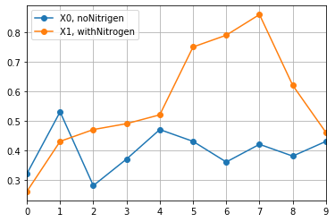

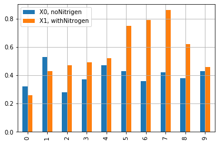

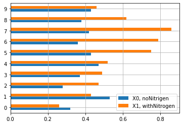

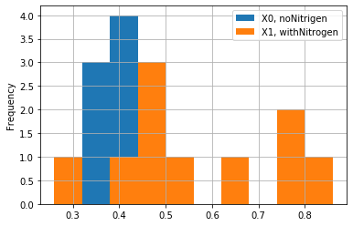

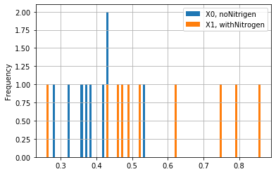

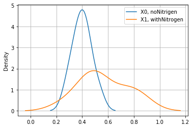

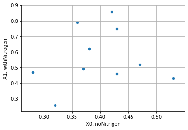

```python
# step2: plot them, visualize them

pdX.plot.line(grid=True, marker='o')
pdX.plot.bar(grid=True)

pdX.plot.barh(grid=True)

pdX.plot.hist(grid=True)
pdX.plot.hist(grid=True, bins=100)

pdX.plot.density(grid=True)

pdX.plot.scatter(x=0, y=1, grid=True)
```

```python
# step3: doing description abot the data

describeX= pdX.describe()
describeX
```

|  | X0, noNitrigen | X1, withNitrogen |
| --- | --- | --- |
| count | 10.000000 | 10.000000 |
| mean | 0.399000 | 0.565000 |
| std | 0.072793 | 0.186741 |
| min | 0.280000 | 0.260000 |
| 25% | 0.362500 | 0.462500 |
| 50% | 0.400000 | 0.505000 |
| 75% | 0.430000 | 0.717500 |
| max | 0.530000 | 0.860000 |

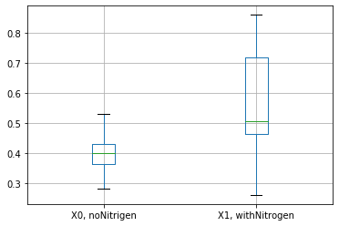

```python
# step4: more plots

pdX.boxplot(grid=True)
```

```python
# step5: compute some important parameters
# sample mean, sample standard deviation (unbiased)

mu0=    X0.mean()
sigma0= X0.std(ddof=1)
mu1=    X1.mean()
sigma1= X1.std(ddof=1)

mu0, sigma0, mu1, sigma1
```

```
(0.39899999999999997,
 0.0727934673503666,
 0.5650000000000001,
 0.18674105660572402)
```

```python
# standard error from mean (sem)

st.sem(X0), st.sem(X1)
```

```
(0.023019315560826058, 0.059052707154051975)
```

```python
# 95% Confidence Inteval (信心區間)

mu0Interval= st.t.interval(0.95,
                           len(X0)-1,
                           loc=np.mean(X0),
                           scale=st.sem(X0))
mu1Interval= st.t.interval(0.95,
                           len(X1)-1,
                           loc=np.mean(X1),
                           scale=st.sem(X1))
mu0Interval, mu1Interval
```

```
((0.34692669042268215, 0.4510733095773178),
 (0.4314134955322152, 0.6985865044677849))
```

```python
# hypothesis testing

st.ttest_ind(X0,X1)
```

```
Ttest_indResult(statistic=-2.6190944840455472, pvalue=0.017386483684799125)
```

【ryComments】:

How to get information about those useful functions/methods/objects

st.ttest_ind?

Signature: st.ttest_ind(a, b, axis=0, equal_var=True, nan_policy='propagate')

Docstring: Calculate the T-test for the means of *two independent* samples of scores.

This is a two-sided test for the null hypothesis that 2 independent samples have identical average (expected) values.

This test *assumes that the populations have identical variances by default.*

【rySol】:

The conclusion is that we must REJECT the hypothesis (or the assumption) that X0 and X1 are from the same population. In another words, they are different!!!

【ryComment】

它代表了：

當 `使用含氮物質時，【不】影響植物生長。` 這個假設為真時， 我們得到的實驗數據經計算之後的某個【統計量】， 會呈現當前實況的【機率】。

機率很小的事本不該發生，而今居然發生！ 因此，逆推回去：

`使用含氮物質時，【不】影響植物生長。`

這個【假設】應該【不為真】。

[figure not shown]

繞了一大圈，我們得到了：【有氮的加入，會幫助植物的成長。】這樣的一個結論。

機率與統計的運用，是幫助我們對這個結論增加了科學性的定量解釋。

它實際上是表明：【若加氮無幫助植物成長，幾乎不可能出現這些實驗結果來當作證據。】

現在【既然發生了這種證據】，可見【加氮無幫助植物成長之假設】不應成立。

否定(或拒絕)了這個假設， 我們就得到 【有氮的加入，會幫助植物的成長。】 這樣的一個結論。

以上就是統計推論應用於科學研究的實例。

## 1.2 Sampling Procedures); Collection of Data

[figure not shown]

#### Sampling methods

- major methods:
  - Simple random sampling ..

[figure not shown]

  - Systematic sampling ..

[figure not shown]

  - Stratified sampling ..

[figure not shown]

  - Cluster sampling ..

[figure not shown]

- the others:
  - Probability-proportional-to-size sampling
  - Quota sampling
  - Minimax sampling
  - Accidental sampling
  - Voluntary Sampling
  - Line-intercept sampling
  - Panel sampling
  - Snowball sampling
  - Theoretical sampling

### Exam 01.03

[figure not shown]

【p01.006】

[figure not shown]

【p01.007】

[figure not shown]

【p01.008】

**Problem restatement**

- A corrosion study was made in order to determine whether `coating` an aluminum metal with a corrosion retardation substance `reduced the amount of corrosion`.
- The coating is a protectant that is advertised to minimize fatigue damage in this type of material.
- Also of interest is the influence of `humidity` on the amount of corrosion.
- A corrosion measurement can be expressed in thousands of cycles to failure.
- `Two levels of coating`, no coating and chemical corrosion coating, were used.
- In addition, the `two relative humidity levels` are 20% relative humidity and 80% relative humidity.
- The experiment involves `four treatment combinations` that are listed in the table that follows.
- There are `eight experimental units` used, and they are aluminum specimens prepared; two are assigned randomly to each of the four treatment combinations.
- The data are presented in Table 1.2.
- The corrosion data are averages of two specimens.
- A plot of the averages is pictured in Figure 1.3.
- A relatively large value of cycles to failure represents a small amount of corrosion.

**Conclution 1**

- As one might expect, an increase in humidity appears to make the corrosion worse.

**Conclution 2**

- The use of the chemical corrosion coating procedure appears to reduce corrosion.

[figure not shown]

## 1.2.1

### Measures of Location: The Sample Mean

[figure not shown]

### Measures of Variability: The Sample Standard Deviation

[figure not shown]

### Exercises 1.1

The following measurements were recorded for the drying time, in hours, of a certain brand of latex paint.

| .. | .. | .. | .. |  |
| --- | --- | --- | --- | --- |
| 3.4 | 2.5 | 4.8 | 2.9 | 3.6 |
| 2.8 | 3.3 | 5.6 | 3.7 | 2.8 |
| 4.4 | 4.0 | 5.2 | 3.0 | 4.8 |

Assume that the measurements are a simple random sample.

- (a) What is the `sample size` for the above sample?
- (b) Calculate the `sample mean` for these data.
- (c) Calculate the `sample median`.
- (d) `Plot` the data by way of a dot plot.
- (e) Compute the 20% `trimmed mean` for the above data set.
- (f) Is the `sample mean` for these data more or less descriptive as a center of location than the `trimmed mean`?
- (g) Compute the `sample variance` and `sample standard deviation`.

## 1.2.2 Statistical Graph

- Dot Plot

[figure not shown]

- Scatter Plot

[figure not shown]

- Stem-and-Leaf Plot

[figure not shown]

- Histogram

[figure not shown]

- Box-and-Whisker Plot or Box Plot

[figure not shown]

## Exercise 1.18

The following scores represent the final examination grades for an elementary statistics course:

| --- | --- | --- | --- | --- | --- | --- | --- | -- |
| --- | --- | --- | --- | --- | --- | --- | --- | --- |
| 23 | 60 | 79 | 32 | 57 | 74 | 52 | 70 | 82 |
| 36 | 80 | 77 | 81 | 95 | 41 | 65 | 92 | 85 |
| 55 | 76 | 52 | 10 | 64 | 75 | 78 | 25 | 80 |
| 98 | 81 | 67 | 41 | 71 | 83 | 54 | 64 | 72 |
| 88 | 62 | 74 | 43 | 60 | 78 | 89 | 76 | 84 |
| 48 | 84 | 90 | 15 | 79 | 34 | 67 | 17 | 82 |
| 69 | 74 | 63 | 80 | 85 | 61 |  |  |  |

(a) Construct a `stem-and-leaf plot` for the examination grades in which the stems are 1, 2, 3, . . . , 9.

(b) Construct a `relative frequency histogram`, draw an estimate of the graph of the distribution, and discuss the `skewness` of the distribution.

(c) Compute the `sample mean`, `sample median`, and `sample standard deviation`.

```python
#[rySol]
#
# Get data, copy paste, and edit it...
X=[
23,	60,	79,	32,	57,	74,	52,	70,	82,
36,	80,	77,	81,	95,	41,	65,	92,	85,
55,	76,	52,	10,	64,	75,	78,	25,	80,
98,	81,	67,	41,	71,	83,	54,	64,	72,
88,	62,	74,	43,	60,	78,	89,	76,	84,
48,	84,	90,	15,	79,	34,	67,	17,	82,
69,	74,	63,	80,	85,	61
]
```

```python
# sample size, sum, mean
len(X), sum(X), sum(X)/len(X)
```

```
(60, 3929, 65.48333333333333)
```

```python
# mean, var, std
m= sum(X)/len(X)
S2= sum([(x-m)**2 for x in X])/(len(X)-1)
S= S2**.5
m, S
```

```
(65.48333333333333, 21.133547647240682)
```

```python
# median

middle= len(X)//2

sX= sorted(X)

X2= sX[middle-1:middle+1]

ans= sum(X2)/2

middle, sX, X2, ans
```

```
(30,
 [10,
  15,
  17,
  23,
  25,
  32,
  34,
  36,
  41,
  41,
  43,
  48,
  52,
  52,
  54,
  55,
  57,
  60,
  60,
  61,
  62,
  63,
  64,
  64,
  65,
  67,
  67,
  69,
  70,
  71,
  72,
  74,
  74,
  74,
  75,
  76,
  76,
  77,
  78,
```

[output cut: 8 more lines]

```
  82,
  82,
  83,
  84,
  84,
  85,
  85,
  88,
  89,
  90,
  92,
  95,
  98],
 [71, 72],
 71.5)
```

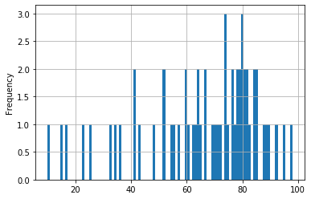

```python
import pandas as pd

pdX= pd.Series(X)
pdX.plot.hist(bins=100, grid=True)
```

```python
pdX.describe()
```

```
count    60.000000
mean     65.483333
std      21.133548
min      10.000000
25%      54.750000
50%      71.500000
75%      80.250000
max      98.000000
dtype: float64
```

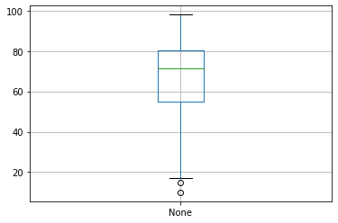

```python
pdX.plot.box(grid=True)
```

## 1.3 Discrete and Continuous Data.

[Continuous or discrete variable](https://en.wikipedia.org/wiki/Continuous_or_discrete_variable)

- Continuous example:
  - (實數是連續型變數之例子)
  - the number of real numbers in $ \{x|a \lt x \lt b ; \space a, b \in \mathbb{R} \} $ is infinite and uncountable
  - the probability distributions of continuous variables can be expressed in terms of `probability density functions` (pdf).
- Discrete example
  - (整數是離散型變數之例子)
  - the number of integer numbers in $ \{x|a \lt x \lt b ; \space a, b \in \mathbb{R} \} $ is finite and countable
  - the number of integer numbers in $ \{x|a \lt x \lt \infty ; \space a \in \mathbb{R} \} $ is infinite and countable
  - the probability distributions of discrete variables can be expressed in terms of `probability mass functions` (pmf).

## 1.4 Probability: [Sample Space](https://en.wikipedia.org/wiki/Sample_space) and Events)

- the `sample space` of an experiment or random trial is the set of all possible outcomes or results of that experiment.
- an `event` is a set of outcomes of an experiment (a subset of the sample space) to which a probability is assigned.

[figure not shown]

### Def 01.01

[figure not shown]

【p01.009】

### Exam01.04

[figure not shown]

Consider the experiment of 【tossing a die】.

If we are interested in the number that shows on the top face, the sample space is

$ S_1 = \{1, 2, 3, 4, 5, 6\}. $

If we are interested only in whether the number is even or odd, the sample space is simply

$ S_2 = \{ even, odd \}. $

### Exam01.05

[figure not shown]

An experiment consists of flipping a coin and then flipping it a second time if a head occurs.

If a tail occurs on the first flip, then a die is tossed once.

To list the elements of the sample space providing the most information, we construct the tree diagram of Figure 2.1.

The various paths along the branches of the tree give the distinct sample points.

Starting with the top left branch and moving to the right along the first path, we get the sample point HH, indicating the possibility that heads occurs on two successive flips of the coin.

Likewise, the sample point T3 indicates the possibility that the coin will show a tail followed by a 3 on the toss of the die.

By proceeding along all paths, we see that the sample space is

$ S = \{HH, HT, T1, T2, T3, T4, T5, T6\}. $

[figure not shown]

【p01.012】

[figure not shown]

【p01.013】

### Exam01.06

Given the sample space S = {t | t ≥ 0}, where t is the life in years of a certain electronic component, then the event A that the component fails before the end of the fifth year is the subset A = {t | 0 ≤ t < 5}.

### Def 01.02

[figure not shown]

【p01.015】

## 1.4.1 Review of set theory (集合論)

### Def 01.03 Complement

[figure not shown]

【p01.016】

### Def 01.04 Intersection

[figure not shown]

【p01.019】

### Def 01.05 `disjoint` or `mutually exclusive`

[figure not shown]

【p01.020】

### Def 01.06 union

[figure not shown]

【p01.022】

## 1.4.1 several set theories:

Several results that follow from the foregoing definitions, which may easily be verified by means of Venn diagrams, are as follows:

```
1. A ∩ φ = φ
2. A ∪ φ = A
3. A ∩ A' = φ
4. A ∪ A' = S
5. S' = φ
6. φ' = S
7. (A')' = A
8. (A ∩ B)' = A' ∪ B'
9. (A ∪ B)' = A' ∩ B'
```

### The last 2 (8. and 9.) are [De Morgan's laws](https://en.wikipedia.org/wiki/De_Morgan%27s_laws)

[figure not shown]

In `formal language`, the rules are written as

1. $ \neg (P\land Q)\iff (\neg P)\lor (\neg Q)$
2. $ \neg (P\lor Q)\iff (\neg P)\land (\neg Q),$

where

P and Q are propositions,

- $\neg$ is the negation logic operator (NOT, 非),
- $\land$ is the conjunction logic operator (AND, 且),
- $\lor$ is the disjunction logic operator (OR, 或),
- $\iff$ is a metalogical symbol meaning "can be replaced in a logical proof with, 彼此相同意義，可互相替換".

### Exercise 2.19, 2.20

2.19

Suppose that a family is leaving on a summer vacation in their camper and that M is the event that they will experience mechanical problems, T is the event that they will receive a ticket for committing a traffic violation, and V is the event that they will arrive at a campsite with no vacancies. Referring to the Venn diagram of Figure 2.5, state in words the events represented by the following regions:

(a) region 5; (b) region 3; (c) regions 1 and 2 together; (d) regions 4 and 7 together; (e) regions 3, 6, 7, and 8 together.

2.20

Referring to Exercise 2.19 and the Venn diagram of Figure 2.5, list the numbers of the regions that represent the following events:

(a) The family will experience no mechanical problems and will not receive a ticket for a traffic violation but will arrive at a campsite with no vacancies.

(b) The family will experience both mechanical problems and trouble in locating a campsite with a vacancy but will not receive a ticket for a traffic violation.

(c) The family will either have mechanical trouble or arrive at a campsite with no vacancies but will not receive a ticket for a traffic violation.

(d) The family will not arrive at a campsite with no vacancies.

[figure not shown]

## 1.5 Counting Sample Points (計數原理、排列組合)

### Def 01.07

[figure not shown]

【p01.029】

A `permutation` is an arrangement of all or part of a set of objects.

For any non-negative integer n, n!, called `n factorial` is defined as

$ n! = n(n − 1) · · · (2)(1), $

with special case: $0! = 1$.

The number of permutations of n objects is $n!$

The number of ways of selecting r objects from n without regard to order. These selections are called `combinations`.

The number of `combinations` of $n$ distinct objects taken $k$ at a time is

$$ \binom{n}{k} = \binom{n}{k, n-k} = \frac{n!}{k! (n − k)!} $$

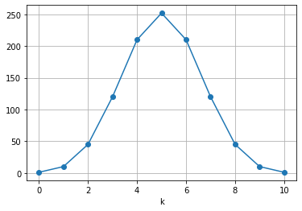

```python
import scipy.special as sp

#p= .5
#q= 1-p

n= 10
k= np.arange(0,n+1)
f= sp.comb(n, k) #* p**k * q**(n-k)

import matplotlib.pyplot as pl
pl.plot(k, f, 'o-')
pl.xlabel('k')
pl.grid()
```

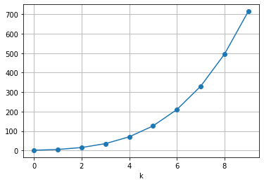

```python
#p= .5
#q= 1-p

r= 5
k= np.arange(0,10)
f= sp.comb(k+r-1, r-1) #* p**k * q**r

#f1= (k +  1)**(r-1)/sp.factorial(r-1)
#f2= (k +r-1)**(r-1)/sp.factorial(r-1)
#f3= (k +r/2)**(r-1)/sp.factorial(r-1)

import matplotlib.pyplot as pl
pl.plot(k, f, 'o-')#,k,f3,'x:')

pl.xlabel('k')
pl.grid()
```

### Exercise

2.48

How many ways are there that no two students will have the same birth date in a class of size 60?

[rySol]

60位 學生按座號排成1直線，

01號學生有 365 天 可選 02號學生有 364 天 可選 ... 60號學生有 306 天 可選

所有選項乘起來 (共60個數字相乘)= 365 *364* ... * 306

$P_{60}^{365}=\binom{365}{60} * 60! = \frac{365!}{305!}$

```python
import scipy.special as sp

sp.perm(365,60), \
sp.comb(365,60)*sp.factorial(60), \
sp.factorial(365)/sp.factorial(305)
# 第３條公式電腦算成　無限大
```

```
(3.211830504503099e+151, 3.211830504503164e+151, nan)
```

```python
# 直接用陽春的　python for 迴圈...
s=1
for i in range(306,366):
    s *= i
s
```

```
32118305045030991521304314923696453096352404945688601384070309911636973370262044734220857508597566903976433710728280765229697954371914956800000000000000
```

```python
# math 模組中有個 log10() 函數
import math
math.log10(s)
```

```
151.50675261851782
```

```python
# 查看型態、轉成　float 型態
type(s), s, float(s)
```

```
(int,
 32118305045030991521304314923696453096352404945688601384070309911636973370262044734220857508597566903976433710728280765229697954371914956800000000000000,
 3.211830504503099e+151)
```

## 1.6 Probability of an Event

### Def 01.08

[figure not shown]

【p01.045】

### Def 01.09

[figure not shown]

【p01.048】

【同等發生機會】 (Equally Likely) 這個關鍵詞 很重要！！

## 1.8 Conditional Probability, Independence, and the Product Rule

條件機率、獨立性、乘法規則。

### Def 01.10

[figure not shown]

【p01.064】

[figure not shown]

### Def 01.11

[figure not shown]

【p01.068】

### Def 01.12

[figure not shown]

【p01.077】

## Thms 01.xx

### Thm 01.01

[figure not shown]

【p01.030】

#### In Python, the factorial function is in module: `math`

```python
import math
math.factorial(4)
```

```
24
```

In module `itertools`, there are Combinatoric generators:

- product(p, q, ... [repeat=1]) --> cartesian product
- permutations(p[, r])
- combinations(p, r)
- combinations_with_replacement(p, r)

```python
import itertools
aList= list(itertools.permutations([0,1,2,3]))
len(aList), aList
```

```
(24,
 [(0, 1, 2, 3),
  (0, 1, 3, 2),
  (0, 2, 1, 3),
  (0, 2, 3, 1),
  (0, 3, 1, 2),
  (0, 3, 2, 1),
  (1, 0, 2, 3),
  (1, 0, 3, 2),
  (1, 2, 0, 3),
  (1, 2, 3, 0),
  (1, 3, 0, 2),
  (1, 3, 2, 0),
  (2, 0, 1, 3),
  (2, 0, 3, 1),
  (2, 1, 0, 3),
  (2, 1, 3, 0),
  (2, 3, 0, 1),
  (2, 3, 1, 0),
  (3, 0, 1, 2),
  (3, 0, 2, 1),
  (3, 1, 0, 2),
  (3, 1, 2, 0),
  (3, 2, 0, 1),
  (3, 2, 1, 0)])
```

### Thm 01.02

[figure not shown]

【p01.031】

```python
import scipy.special
nPk= scipy.special.perm(N=4, k=2)
nPk
```

```
12.0
```

### Thm 01.03

[figure not shown]

【p01.036】

### Thm 01.04

[figure not shown]

【p01.037】

### Thm 01.05

[figure not shown]

【p01.039】

### Thm 01.06

[figure not shown]

【p01.041】

```python
import scipy.special
scipy.special.comb(N=4,k=2)
```

```
6.0
```

```python
import itertools

list(itertools.combinations([1,2,3,4],2))
```

```
[(1, 2), (1, 3), (1, 4), (2, 3), (2, 4), (3, 4)]
```

### Thm 01.07

[figure not shown]

【p01.050】

[figure not shown]

### Thm 01.08

[figure not shown]

【p01.055】

### [Inclusion–exclusion principle](https://en.wikipedia.org/wiki/Inclusion%E2%80%93exclusion_principle)

[包容-排斥 原理](https://zh.wikipedia.org/wiki/%E6%8E%92%E5%AE%B9%E5%8E%9F%E7%90%86)

[figure not shown]

In its general form, the principle of inclusion–exclusion states that for finite sets A1, ..., An, one has the identity

### Thm 01.09

[figure not shown]

【p01.059】

### Thm 01.10

[figure not shown]

【p01.069】

### Thm 01.11

[figure not shown]

【p01.071】

### Thm 01.12

[figure not shown]

【p01.076】

## 1.9 Bayes' Rule

### Thm 01.13

[figure not shown]

【p01.079】

### Thm 01.14

[figure not shown]

【p01.084】

[figure not shown]

【p01.085】

## Cols 01.xx

### Col 01.01

[figure not shown]

【p01.052】

### Col 01.02

[figure not shown]

【p01.053】

### Col 01.03

[figure not shown]

【p01.054】

## Exams 01.xx

### Exam01.07

Let R be the event that a red card is selected from an ordinary deck of 52 playing cards, and let S be the entire deck. Then R' is the event that the card selected from the deck is not a red card but a black card.

### Exam01.08

Consider the sample space S = {book, cell phone, mp3, paper, stationery, laptop}. Let A = {book, stationery, laptop, paper}. Then the complement of A is A' = {cell phone, mp3}.

### Exam01.09

Let E be the event that a person selected at random in a classroom is majoring in engineering, and let F be the event that the person is female. Then E ∩ F is the event of all female engineering students in the classroom.

### Exam01.10

Let V = {a, e, i, o, u} and C = {l, r, s, t}; then it follows that V ∩ C = φ. That is, V and C have no elements in common and, therefore, cannot both simultaneously occur.

### Exam01.11

A cable television company offers programs on eight different channels, three of which are affiliated with ABC, two with NBC, and one with CBS. The other two are an educational channel and the ESPN sports channel. Suppose that a person subscribing to this service turns on a television set without first selecting the channel. Let A be the event that the program belongs to the NBC network and B the event that it belongs to the CBS network. Since a television program cannot belong to more than one network, the events A and B have no programs in common. Therefore, the intersection A ∩ B contains no programs, and consequently the events A and B are mutually exclusive.

### Exam01.12

Let A = {a, b, c} and B = {b, c, d, e}; then A ∪ B = {a, b, c, d, e}.

### Exam01.13

Let P be the event that an employee selected at random from an oil drilling company smokes cigarettes. Let Q be the event that the employee selected drinks alcoholic beverages. Then the event P ∪ Q is the set of all employees who either drink or smoke or do both.

### Exam01.14

If M = {x | 3 < x < 9} and N = {y | 5 < y < 12}, then M ∪ N = {z | 3 < z < 12}.

### Exam01.15

(Example 2.18:)

In one year, three awards (research, teaching, and service) will be given to a class of 25 graduate students in a statistics department. If each student can receive at most one award, how many possible selections are there?

#### 【Solution】 :

Since the awards are distinguishable, it is a permutation problem.

The total number of sample points is

$ P^{25}_{3} = \frac {25!} {(25 − 3)!} = \frac {25!} {22!} = (25)(24)(23) = 13, 800. $

#### 運用 Python 之 scipy.special 模組 來做計算

```
import scipy.special as sp

sp.comb(N, k)
  #The number of combinations of N things taken k at a time.
sp.perm(N, k)
  #Permutations of N things taken k at a time, i.e., k-permutations of N.
sp.factorial(n)
  #The factorial of a number or array of numbers.
```

#### 利用 sp.perm? 或 sp.perm?? 來查看函數的說明

```python
# sp.perm?

# 活用
import scipy.special as sp

ans1= sp.perm(25,3)

ans2= sp.factorial(25)/sp.factorial(22)

ans3= 25*24*23

ans1, ans2, ans3
```

```
(13800.0, 13799.999999999998, 13800)
```

## Exers 01.xx

### Exercises:

## - 數學的學習過程中，做習題是非常重要的，不可或缺的過程，課本中，所有章節或段落都有許多習題，各位同學盡量多做，最低限度，每個段落的的習題至少都做3題以上。

## - 請優先練習 第1題、最後1題以及題號為中位數(首尾題號相加除以2)的題目

## - 以本節為例，優先選擇

```
- 01.01, (首題)
- 01.16, (尾題)
- 01.08. (中間題)
```

### Exer01.01

(2.1)

List the elements of each of the following sample spaces:

(a) the set of integers between 1 and 50 divisible by 8;

(b) the set $ S = \{x | x^2 + 4x − 5 = 0\} $

(c) the set of outcomes when a coin is tossed until a tail or three heads appear;

(d) the set S = {x | x is a continent};

(e) the set S = {x | 2x − 4 ≥ 0 and x < 1}.

### Exer01.16

(2.20)

Referring to Exercise 2.19 and the Venn diagram of Figure 2.5, list the numbers of the regions that represent the following events:

(a) The family will experience no mechanical problems and will not receive a ticket for a traffic violation but will arrive at a campsite with no vacancies.

(b) The family will experience both mechanical problems and trouble in locating a campsite with a vacancy but will not receive a ticket for a traffic violation.

(c) The family will either have mechanical trouble or arrive at a campsite with no vacancies but will not receive a ticket for a traffic violation.

(d) The family will not arrive at a campsite with no vacancies.

2.19

Suppose that a family is leaving on a summer vacation in their camper and that M is the event that they will experience mechanical problems, T is the event that they will receive a ticket for committing a traffic violation, and V is the event that they will arrive at a campsite with no vacancies. Referring to the Venn diagram of Figure 2.5, state in words the events represented by the following regions:

(a) region 5;

(b) region 3;

(c) regions 1 and 2 together;

(d) regions 4 and 7 together;

(e) regions 3, 6, 7, and 8 together.

[figure not shown]

#### Exer01.08

(2.10)

An engineering firm is hired to determine if certain waterways in Virginia are safe for fishing. Samples are taken from three rivers.

(a) List the elements of a sample space S, using the letters F for safe to fish and N for not safe to fish.

(b) List the elements of S corresponding to event E that at least two of the rivers are safe for fishing.

(c) Define an event that has as its elements the points {FFF,NFF,FFN,NFN}.

### Exam01.16

Example 2.19:

A president and a treasurer are to be chosen from a student club consisting of 50 people. How many different choices of officers are possible if

(a) there are no restrictions;

(b) A will serve only if he is president;

(c) B and C will serve together or not at all;

(d) D and E will not serve together?

### Exam01.17

Example 2.20:

In a college football training session, the defensive coordinator needs to have 10 players standing in a row. Among these 10 players, there are 1 freshman, 2 sophomores, 4 juniors, and 3 seniors. How many different ways can they be arranged in a row if only their class level will be distinguished?

### Exam01.18

Example 2.21:

In how many ways can 7 graduate students be assigned to 1 triple and 2 double hotel rooms during a conference?

【Solution】 :